# Rohit Dhankar - R Code

Free License

Rohit Dhankar

[figure not shown]

# Major Rohit Dhankar from [Github.io](https://github.com/RohitDhankar)

```r
# R Code Starts here ...

# Marketing Mix - Brands
# Customer ratings for - perceptual adjectives and 4 brands.
# Within marketing analytics - perceptual adjectives to be linked to perceptual maps.

d <- read.csv("C:/Users/Rohit/Desktop/Marketing Mix - Brands/d.csv")
head(d)
```

```r
summary(d)
```

```
 cheap            snappy         effective        luxurious
```

Min. : 1.000 Min. : 1.000 Min. : 1.000 Min. : 1.000  
1st Qu.: 4.000 1st Qu.: 4.000 1st Qu.: 4.000 1st Qu.: 3.000  
Median : 8.000 Median : 8.000 Median : 6.000 Median : 6.000  
Mean : 7.079 Mean : 7.074 Mean : 5.786 Mean : 5.642  
3rd Qu.:10.000 3rd Qu.:10.000 3rd Qu.: 8.000 3rd Qu.: 8.000  
Max. :10.000 Max. :10.000 Max. :10.000 Max. :10.000  
artistic bold caring casual  
Min. : 1.000 Min. : 1.000 Min. : 1.000 Min. : 1.00  
1st Qu.: 3.000 1st Qu.: 3.000 1st Qu.: 3.000 1st Qu.: 3.00  
Median : 6.000 Median : 5.000 Median : 6.000 Median : 6.00  
Mean : 5.529 Mean : 5.486 Mean : 5.505 Mean : 5.54  
3rd Qu.: 8.000 3rd Qu.: 8.000 3rd Qu.: 8.000 3rd Qu.: 8.00  
Max. :10.000 Max. :10.000 Max. :10.000 Max. :10.00  
charming contemporary creative daring  
Min. : 1.000 Min. : 1.0 Min. : 1.000 Min. : 1.000  
1st Qu.: 3.000 1st Qu.: 3.0 1st Qu.: 4.000 1st Qu.: 3.000  
Median : 6.000 Median : 6.0 Median : 7.000 Median : 5.000  
Mean : 5.637 Mean : 5.8 Mean : 6.085 Mean : 5.473  
3rd Qu.: 8.000 3rd Qu.: 8.0 3rd Qu.: 9.000 3rd Qu.: 8.000  
Max. :10.000 Max. :10.0 Max. :10.000 Max. :10.000  
elegant energetic exciting festive  
Min. : 1.000 Min. : 1.000 Min. : 1.000 Min. : 1.000  
1st Qu.: 3.000 1st Qu.: 4.000 1st Qu.: 4.000 1st Qu.: 3.000  
Median : 5.000 Median : 7.000 Median : 7.000 Median : 5.500  
Mean : 5.502 Mean : 6.082 Mean : 6.072 Mean : 5.478  
3rd Qu.: 8.000 3rd Qu.: 9.000 3rd Qu.: 9.000 3rd Qu.: 8.000  
Max. :10.000 Max. :10.000 Max. :10.000 Max. :10.000  
fresh fun graceful hip  
Min. : 1.000 Min. : 1.000 Min. : 1.000 Min. : 1.000  
1st Qu.: 4.000 1st Qu.: 3.000 1st Qu.: 3.000 1st Qu.: 3.000  
Median : 7.000 Median : 6.000 Median : 5.000 Median : 6.000  
Mean : 6.103 Mean : 5.961 Mean : 5.494 Mean : 6.005  
3rd Qu.: 9.000 3rd Qu.: 9.000 3rd Qu.: 8.000 3rd Qu.: 9.000  
Max. :10.000 Max. :10.000 Max. :10.000 Max. :10.000  
brand.name  
Min. :1.000  
1st Qu.:2.000  
Median :3.000  
Mean :2.508  
3rd Qu.:4.000  
Max. :4.000

```r
# scaling the raw data  - creating a scaled matrix
dsc<-scale(d[,1:20])
# creating a Data Frame of same name - "dsc" from scaled matrix
dsc<-as.data.frame(dsc)
summary(dsc)
```

```
 cheap             snappy          effective          luxurious
```

Min. :-1.9334 Min. :-1.9356 Min. :-1.77078 Min. :-1.5973  
1st Qu.:-0.9793 1st Qu.:-0.9797 1st Qu.:-0.66072 1st Qu.:-0.9092  
Median : 0.2929 Median : 0.2950 Median : 0.07933 Median : 0.1230  
Mean : 0.0000 Mean : 0.0000 Mean : 0.00000 Mean : 0.0000  
3rd Qu.: 0.9290 3rd Qu.: 0.9323 3rd Qu.: 0.81937 3rd Qu.: 0.8112  
Max. : 0.9290 Max. : 0.9323 Max. : 1.55941 Max. : 1.4993  
artistic bold caring casual  
Min. :-1.5710 Min. :-1.5652 Min. :-1.5577 Min. :-1.5768  
1st Qu.:-0.8772 1st Qu.:-0.8674 1st Qu.:-0.8662 1st Qu.:-0.8821  
Median : 0.1634 Median :-0.1696 Median : 0.1711 Median : 0.1599  
Mean : 0.0000 Mean : 0.0000 Mean : 0.0000 Mean : 0.0000  
3rd Qu.: 0.8571 3rd Qu.: 0.8771 3rd Qu.: 0.8626 3rd Qu.: 0.8545  
Max. : 1.5509 Max. : 1.5749 Max. : 1.5541 Max. : 1.5492  
charming contemporary creative daring  
Min. :-1.5899 Min. :-1.76217 Min. :-1.7559 Min. :-1.5594  
1st Qu.:-0.9042 1st Qu.:-1.02798 1st Qu.:-0.7200 1st Qu.:-0.8622  
Median : 0.1243 Median : 0.07331 Median : 0.3159 Median :-0.1649  
Mean : 0.0000 Mean : 0.00000 Mean : 0.0000 Mean : 0.0000  
3rd Qu.: 0.8100 3rd Qu.: 0.80750 3rd Qu.: 1.0065 3rd Qu.: 0.8811  
Max. : 1.4957 Max. : 1.54170 Max. : 1.3518 Max. : 1.5783  
elegant energetic exciting festive  
Min. :-1.5707 Min. :-1.7515 Min. :-1.7434 Min. :-1.556096  
1st Qu.:-0.8729 1st Qu.:-0.7176 1st Qu.:-0.7122 1st Qu.:-0.861158  
Median :-0.1750 Median : 0.3162 Median : 0.3190 Median : 0.007514  
Mean : 0.0000 Mean : 0.0000 Mean : 0.0000 Mean : 0.000000  
3rd Qu.: 0.8717 3rd Qu.: 1.0055 3rd Qu.: 1.0064 3rd Qu.: 0.876186  
Max. : 1.5695 Max. : 1.3501 Max. : 1.3502 Max. : 1.571123  
fresh fun graceful hip  
Min. :-1.7679 Min. :-1.66693 Min. :-1.564 Min. :-1.691154  
1st Qu.:-0.7286 1st Qu.:-0.99490 1st Qu.:-0.868 1st Qu.:-1.015407  
Median : 0.3107 Median : 0.01315 Median :-0.172 Median :-0.001785  
Mean : 0.0000 Mean : 0.00000 Mean : 0.000 Mean : 0.000000  
3rd Qu.: 1.0035 3rd Qu.: 1.02120 3rd Qu.: 0.872 3rd Qu.: 1.011836  
Max. : 1.3499 Max. : 1.35722 Max. : 1.568 Max. : 1.349710

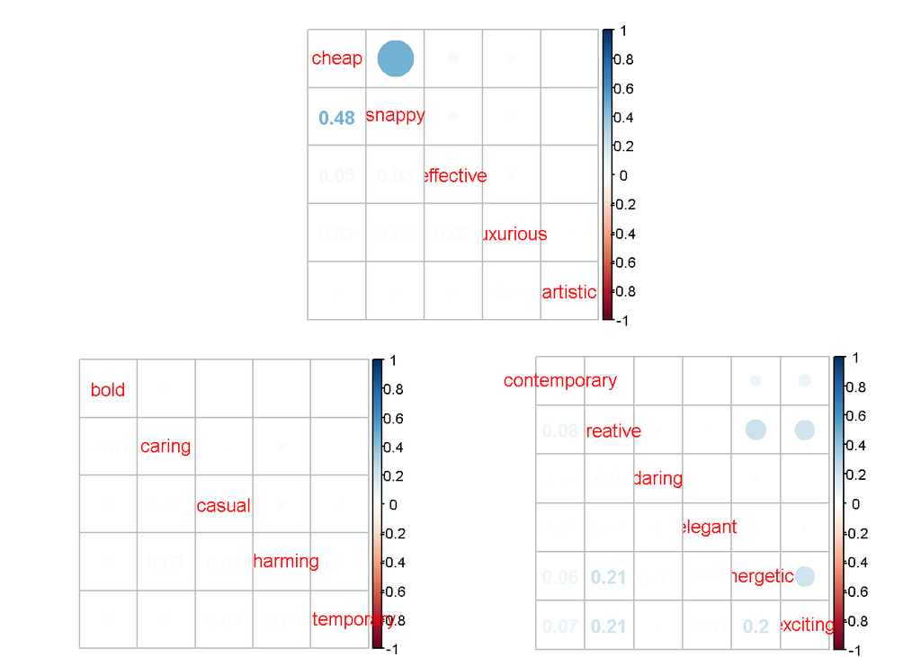

```r
# as seen in summary - "mean" for all - dimensions - is now "0.00"

# Now we create a merged data frame "dsc1" - adding the "brand.name" variable to the
# scaled data frame created earlier
dsc1<-cbind(dsc,d$brand.name)
# change the - "d$brand.name" to just "brand.name"
names(dsc1) [21] <- "brand.name"

library(corrplot)

# varied permutations of the bi variable correlation plot....
# too many variables thus creating seperate Correlation Plots
c1<-cor(dsc1[, 1:5])
c2<-cor(dsc1[, 6:10])
c3<-cor(dsc1[, 10:15])
c4<-cor(dsc1[, 16:20])

layout(matrix(c(1, 1, 2, 3), 2, 2, byrow = TRUE))
corrplot.mixed(c1,lower="number", upper="circle")
corrplot.mixed(c2,lower="number", upper="circle")
corrplot.mixed(c3,lower="number", upper="circle")
```

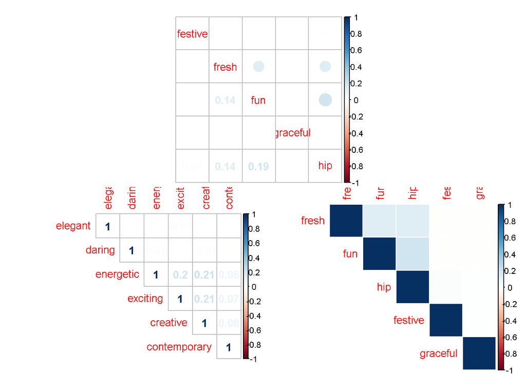

```r
corrplot.mixed(c4,lower="number", upper="circle")

corrplot(c3,type="upper", method="number",order="AOE")
# "AOE" for the angular order of the eigenvectors
corrplot(c4,type="upper", method="shade",order="hclust")
```

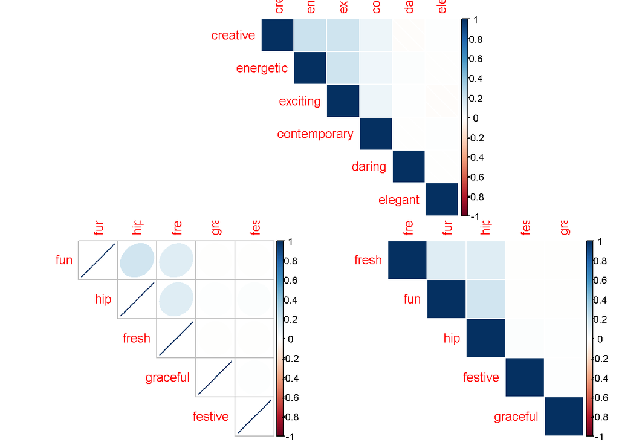

```r
# "hclust" for the hierarchical clustering order.
corrplot(c3,type="upper", method="shade",order="FPC")
# "FPC" for the first principal component order.
corrplot(c4,type="upper", method="ellipse",order="FPC")
# "FPC" for the first principal component order.
#  method="ellipse"
corrplot(c4,type="upper", method="color",order="hclust")
```

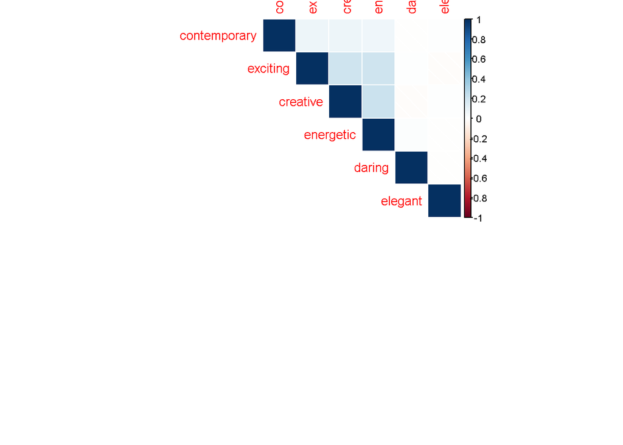

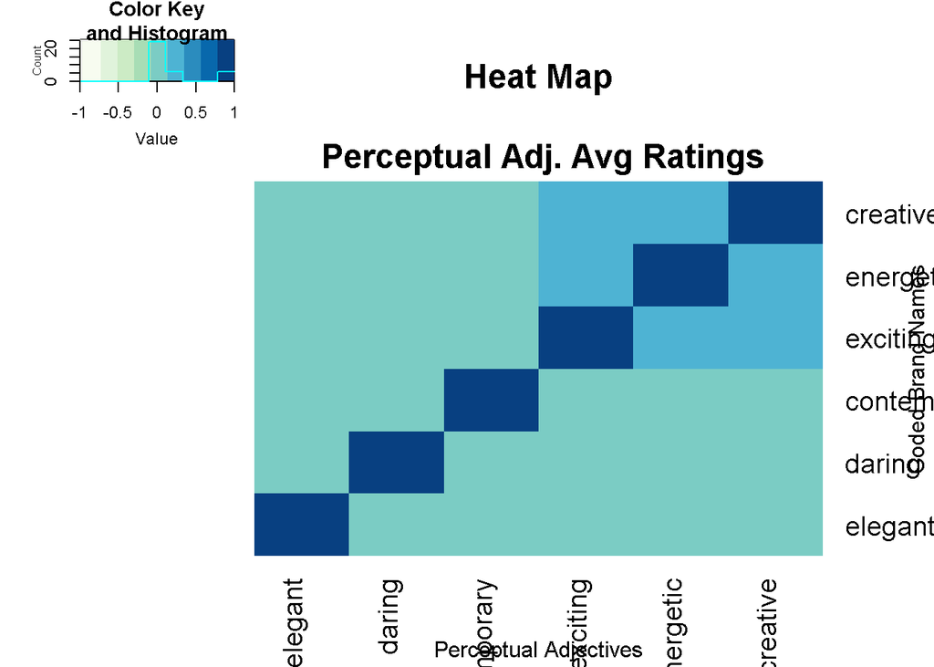

```r
# "FPC" for the first principal component order.
#  method="color"
corrplot(c3,type="upper", method="shade",order="hclust")
# "FPC" for the first principal component order.
#  method="shade"  - not very different from "color"

###
# Whats the average or the "mean" rating for each brand
# for all given - 20 - perceptual adjectives ?
###

avg.ratings <- aggregate(.~ brand.name , data=dsc1 , mean)
View(avg.ratings)
library(gplots)
library("RColorBrewer", lib.loc="~/R/win-library/3.1")
heatmap.2(as.matrix(c3),col=brewer.pal(9, "GnBu"),
          xlab=" Perceptual Adjectives ", ylab= "Coded Brand Names",trace="none", key=T, dend="none",main="\n\n\n Heat Map \n\n Perceptual Adj. Avg Ratings")
```

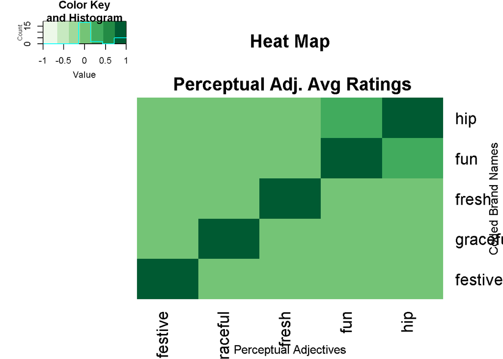

```r
heatmap.2(as.matrix(c4),col=brewer.pal(7,"Greens"),
          xlab=" Perceptual Adjectives ", ylab= "Coded Brand Names",trace="none", key=T, dend="none",main="\n\n\n Heat Map \n\n Perceptual Adj. Avg Ratings")
```

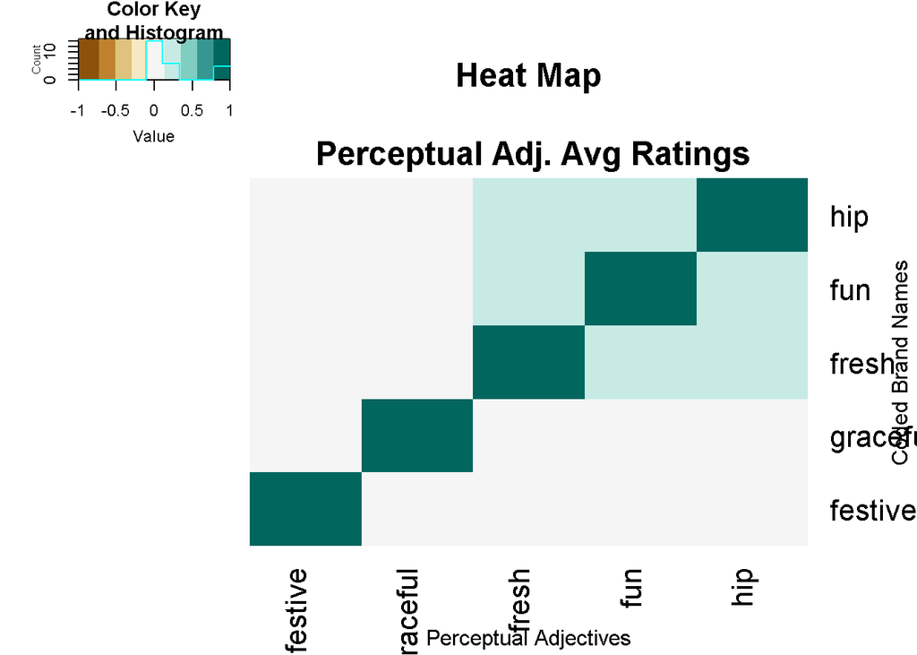

```r
#
heatmap.2(as.matrix(c4),col=brewer.pal(9,"BrBG"),
          xlab=" Perceptual Adjectives ", ylab= "Coded Brand Names",trace="none", key=T, dend="none",main="\n\n\n Heat Map \n\n Perceptual Adj. Avg Ratings")
```

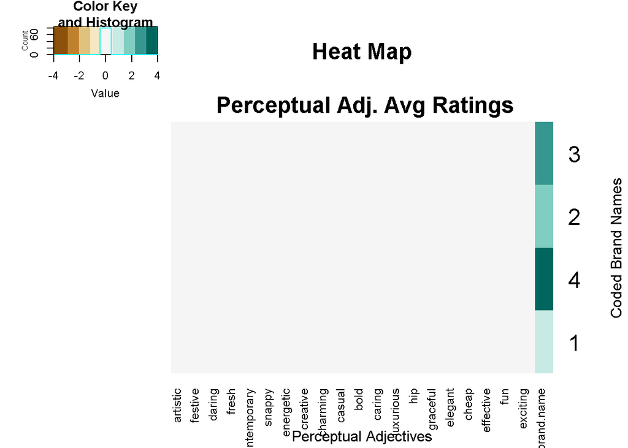

```r
#
heatmap.2(as.matrix(avg.ratings),col=brewer.pal(9,"BrBG"),
          xlab=" Perceptual Adjectives ", ylab= "Coded Brand Names",trace="none", key=T, dend="none",main="\n\n\n Heat Map \n\n Perceptual Adj. Avg Ratings")
```

```r
#
# As the average ratings are mostly in the "0.000" range we need to
# multiply with "1000" across to get a decent data viz with the HeatMap .
getwd()
```

[1] “C:/Users/Rohit/Desktop/Marketing Mix - Brands”

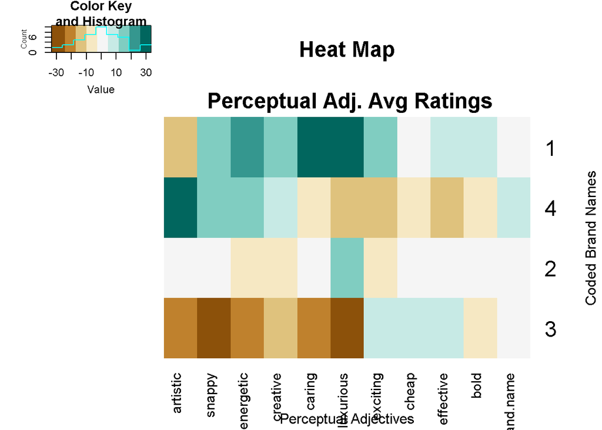

```r
write.table(avg.ratings,"C:/Users/Rohit/Desktop/Marketing Mix - Brands/avg.csv",sep=",")
# Excel calc - external to R - now import avg1.csv
avg1 <- read.csv("C:/Users/Rohit/Desktop/Marketing Mix - Brands/avg1.csv")
View(avg1)
#
heatmap.2(as.matrix(avg1),col=brewer.pal(9,"BrBG"),
          xlab=" Perceptual Adjectives ", ylab= "Coded Brand Names",trace="none", key=T, dend="none",main="\n\n\n Heat Map \n\n Perceptual Adj. Avg Ratings")
```

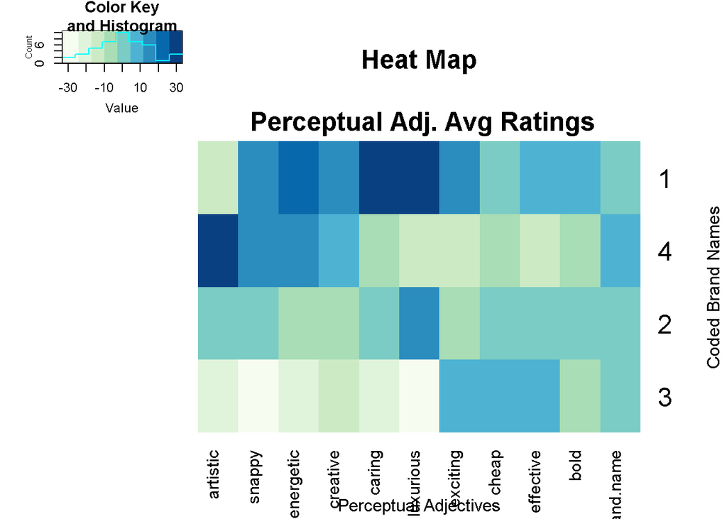

```r
#
heatmap.2(as.matrix(avg1),col=brewer.pal(9, "GnBu"),
          xlab=" Perceptual Adjectives ", ylab= "Coded Brand Names",trace="none", key=T, dend="none",main="\n\n\n Heat Map \n\n Perceptual Adj. Avg Ratings")
```

```r
#


# R Code Ends here ...
```

## License None

[© Major Rohit Dhankar 2015](https://github.com/RohitDhankar)